# Phase 1

### Boxplot of people having stroke w.r.t. heart disease and age

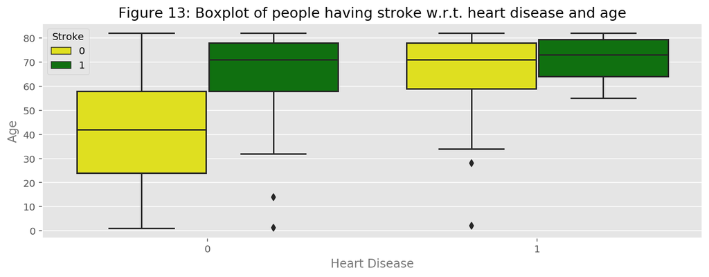

```python
#People with heart disease are more prone to have a stroke
f, (ax2) = plt.subplots(1, 1, figsize=(12, 4))
sns.boxplot(x="heart_disease", y="age", hue="stroke",
               data=stroke_data, palette={0: "yellow", 1: "green"}, ax=ax2)
ax2.set_xlabel("Heart Disease",size = 12,alpha=0.8)
ax2.set_ylabel("Age",size = 12,alpha=0.8)
plt.title("Figure 13: Boxplot of people having stroke w.r.t. heart disease and age")
l = plt.legend(loc='best', title='Stroke')
```

Old age people having a heart disease were seen to be suffering more by stroke than younger people. Although, age is the main factor of having stroke.

### Boxplot of people having stroke w.r.t. hypertension and age

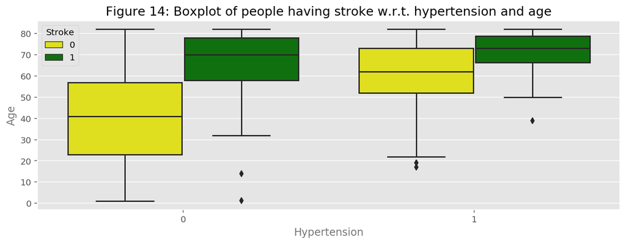

```python
f, (ax2) = plt.subplots(1, 1, figsize=(12, 4))
sns.boxplot(x="hypertension", y="age", hue="stroke",
               data=stroke_data, palette={0: "yellow", 1: "green"}, ax=ax2)
ax2.set_xlabel("Hypertension",size = 12,alpha=0.8)
ax2.set_ylabel("Age",size = 12,alpha=0.8)
l = plt.legend(loc='best', title='Stroke')
plt.title("Figure 14: Boxplot of people having stroke w.r.t. hypertension and age")
plt.show()
```

Old age people having hypertension were seen to be suffering more by stroke than younger people. Although, age is the main factor of having stroke.

## Summary and Conclusion

Exploratory data analysis was performed on stroke dataset. Firstly, we performed data preparation and cleaning in which we checked the data types of each attributes. We performed the sanity checks and then, checked for missing values. We handled those missing values by using mean technique. After this our data was ready for exploration and visualisation. Then, we observed various relationship between the variables and got more insights from our dataset.

According to WHO, Stroke is the second leading cause of death. Taking look at our insights, it is found that the factors above do increase your chance of having a stroke so we should take care of our health by consuming balanced diet, exercising daily and more.

## References

- Source of the dataset - Kaggle.com. 2021. Stroke Prediction Dataset. [online] Available at: https://www.kaggle.com/fedesoriano/stroke-prediction-dataset [Accessed 11 April 2021].
- Lecture Notes - www.featureranking.com. 2021. Regression Case Study | www.featureranking.com. [online] Available at: https://www.featureranking.com/tutorials/statistics-tutorials/regression-case-study [Accessed 11 April 2021].